Plotting holocentric chromosomes Fernando Roa 23 08 2019

Go to home  
Go to monocentrics Vignette  
Go to groups Vignette  
Go to human Vignette  
Go to phylogeny Vignette

This guide shows the files to plot idiograms of karyotypes of holocentrics and optionally marks.

# 1 Load package

visit gitlab for installation instructions https://gitlab.com/ferroao/idiogramFISH

```r
#load package
library(idiogramFISH)
```

# 2 Get your chromosome size data

Initially you have to open your chromosome data as a data.frame.

## From scratch:

```r
# Example data.frame written in R, use: (column OTU is optional if only 1 OTU)
mydfChrSizeHolo<-read.table(text=
"            OTU chrName chrSize
1 \"Species one\"   1     6.5
2 \"Species one\"   2     5.0
3 \"Species one\"   3     4.0
4 \"Species one\"   X     3.0    "  ,  header=TRUE, stringsAsFactors=FALSE,fill=TRUE)
```

| OTU | chrName | chrSize |
| --- | --- | --- |
| Species one | 1 | 6.5 |
| Species one | 2 | 5.0 |
| Species one | 3 | 4.0 |
| Species one | X | 3.0 |

## or loading saved data:

Initially, if you use RStudio, use menu “Session”, “Set working directory” for choosing your desired folder or:

```r
setwd("~/folder/subfolder")
```

Open your chromosome data data.frame importing it from a .csv (read.csv) or .xls file (readxl).

```r
mydfChrSize<-read.csv("somefile.csv")
```

For fixing column names use:

```r
colnames(mydfChrSize)<-c("OTU", "chrName","chrSize")
```

# 3 Get marks general data

This data.frame is optional for ver. > 1.0.0

```r
packageVersion("idiogramFISH")
```

[output not shown]

Open or make your mark data as a data.frame. This data.frame has the marks present in all karyotypes with color and style, without position info. If `style` column is not present it will be filled with `square` during plotting.

```r
# From scratch:
mydfMarkColor<-read.table(text=
"  markName markColor  style
1       5S       red   dots
2      45S     green square
3     DAPI      blue square
4      CMA    yellow square"  ,  header=TRUE, stringsAsFactors=FALSE,fill=TRUE)
```

| markName | markColor | style |
| --- | --- | --- |
| 5S | red | dots |
| 45S | green | square |
| DAPI | blue | square |
| CMA | yellow | square |

For fixing column names use:

```r
colnames(mydfMarkColor)<-c("markName", "markColor","style") # if style column not present it will be filled with "square"
```

# 4 Get marks positions data

Open or write your mark positions as a data.frame. This data.frame has the marks present in all karyotypes with position info.

```r
# We will use column OTU if data.frame because chromosome size df has it
mydfMarkPosHolo<-read.table(text=
"             OTU  chrName markName markPos markSize
1 \"Species one\"       3       5S     1.0      0.5
2 \"Species one\"       3     DAPI     2.0      0.5
3 \"Species one\"       1      45S     2.0      0.5
4 \"Species one\"       2     DAPI     2.0      0.5
5 \"Species one\"       4      CMA     2.0      0.5
6 \"Species one\"       4       5S     0.5      0.5"  ,  header=TRUE, stringsAsFactors=FALSE,fill=TRUE)
```

| OTU | chrName | markName | markPos | markSize |
| --- | --- | --- | --- | --- |
| Species one | 3 | 5S | 1.0 | 0.5 |
| Species one | 3 | DAPI | 2.0 | 0.5 |
| Species one | 1 | 45S | 2.0 | 0.5 |
| Species one | 2 | DAPI | 2.0 | 0.5 |
| Species one | 4 | CMA | 2.0 | 0.5 |
| Species one | 4 | 5S | 0.5 | 0.5 |

For fixing column names use something like:

```r
colnames(mydfMarkColor)<-c("OTU", "chrName","markName","markPos","markSize")
```

# 5 Plotting

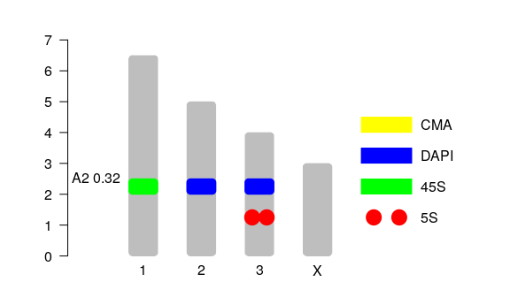

```r
# library(idiogramFISH)
par(mar=c(1,4,1,1)) # bottom left top right

plotIdiogramsHolo(dfChrSize=mydfChrSizeHolo,  # data.frame of chr. sizes
                  dfMarkColor=mydfMarkColor,  # df of mark style
                  dfMarkPos=mydfMarkPosHolo,  # df of mark positions
                  karHeight = 1.4,            # vertical size of karyotype plus spacing
                  addOTUName=FALSE,           # add OTU names

                  chrWidth = 2,               # width of chromosomes
                  chrSpacing = 2,             # space among chromosomes
                  indexIdTextSize=1,          # font size of chr. name and indices

                  dotRoundCorr=2,             # correction factor for roundness of dots
                  legend="aside" ,            # position of legend, not "inline"
                  markLabelSize=1,            # font size of legend

                  rulerNumberSize=1,          # font size of ruler
                  rulerPos=-2.2,              # position of ruler
                  ruler.tck=-0.03,            # size and orient. of tick of ruler
                  rulerNumberPos=.9,          # ruler's number position

                  xlimLeftMod=2.2,            # modify xlim left argument
                  xlimRightMod=10,            # modify xlim right argument
                  ylimBotMod=.1               # modify ylim bottom argument
                  )
```

For ver. > 1.0.0 there is no need to add `dfMarkColor` and you can also use the parameter `mycolors` (optional too), to establish marks’ colors. When using `mycolors`, colors are assigned depending on the order of marks, i.e.:

```r
unique(dfMarkPosHolo$markName)
```

[output not shown]

```r
par(mar=c(1,4,1,1))
plotIdiogramsHolo(dfChrSize=dfChrSizeHolo,
                  dfMarkPos=dfMarkPosHolo,
                  mycolors = c("green","yellow","blue","red"),  # optional
                  dotRoundCorr=2.5, chrWidth=2.5,
                  indexIdTextSize=1,
                  legend="aside" ,markLabelSize=1,
                  addOTUName=F,
                  rulerNumberSize=1, rulerPos=-.7,ruler.tck=-0.04,rulerNumberPos=.9,
                  xlimLeftMod=1,  xlimRightMod=10, ylimBotMod=.2
)
```

[output not shown]

# 6 Example with several species (OTUs)

## To illustrate this, we will load some data.frames from the package

Chromosome sizes

```r
data(bigdfChrSizeHolo)
```

| OTU | chrName | chrSize |
| --- | --- | --- |
| species one | 1 | 3 |
| species one | 2 | 4 |
| species one | 3 | 2 |
| species one | 4 | 5 |
| species two | 1 | 3 |
| species two | 2 | 4 |
| species two | 3 | 2 |
| species two | 4 | 5 |
| species three | 1 | 3 |
| species three | 2 | 4 |
| species three | 3 | 2 |
| species three | 4 | 5 |

Mark characteristics, does not require OTU, df optional for ver. > 1.0.0

```r
data(dfMarkColor)
```

| markName | markColor | style |
| --- | --- | --- |
| 5S | red | dots |
| 45S | green | square |
| DAPI | blue | square |
| CMA | yellow | square |

Mark position

```r
data(bigdfMarkPosHolo)
```

| OTU | chrName | markName | markPos | markSize |
| --- | --- | --- | --- | --- |
| species two | 3 | 5S | 1.0 | 0.5 |
| species two | 3 | DAPI | 2.0 | 0.5 |
| species two | 1 | 45S | 2.0 | 0.5 |
| species two | 2 | DAPI | 2.0 | 0.5 |
| species two | 4 | CMA | 2.0 | 0.5 |
| species two | 4 | 5S | 0.5 | 0.5 |

## 6.1 Plotting

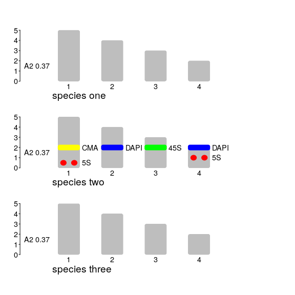

```r
library(idiogramFISH)
par(mar=c(1,1,1,1))

plotIdiogramsHolo(dfChrSize=bigdfChrSizeHolo, # df of chr. sizes
                  dfMarkColor=dfMarkColor,    # df of mark style
                  dfMarkPos=bigdfMarkPosHolo, # df of marks' position

                  MarkDistanceType="cen",     # distance to mark (center of mark)
                  roundness=6,                # vertices roundness of chr. and marks
                  dotRoundCorr=1,             # correction of dots roundness

                  karHeight = 1,              # rel. karyotype height
                  karSpacing = 1.7,           # karyotype height including spacing
                  reduDistKar=FALSE,          # reduce vertical space among karyotypes of karSpacing

                  chrId="simple",             # numbering of chr., not using "original" name
                  chrWidth = 2,               # chr. width
                  chrSpacing = 2,             # space among chr.

                  indexIdTextSize=.9,         # font size of chr names and indices
                  markLabelSize=.9,           # font size of legends
                  rulerNumberSize=.9,         # font size of ruler
                  OTUTextSize=1.2,            # font size of OTUs' names

                  xlimRightMod=2,             # modify xlim right argument
                  ylimBotMod=.4)              # modify ylim bottom argument
```

# 7 Using bases instead of micrometers

Create some data in millions of bases:

```r
# using previous data.frames
bigdfChrSizeHolo$chrSize<-bigdfChrSizeHolo$chrSize*980000
bigdfMarkPosHolo$markPos<-bigdfMarkPosHolo$markPos*980000
bigdfMarkPosHolo$markSize<-bigdfMarkPosHolo$markSize*980000
```

## Plotting

In the plot length is shown in Mb

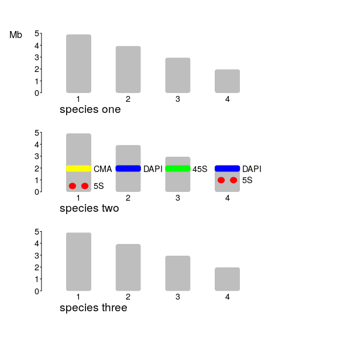

```r
par(mar=c(1,1,1,1))

plotIdiogramsHolo(dfChrSize=bigdfChrSizeHolo,    # df of chr. sizes
                  dfMarkColor=dfMarkColor,       # df of mark style
                  dfMarkPos=bigdfMarkPosHolo,    # df of mark positions

                  MarkDistanceType="cen",        # distance to mark is to its center
                  Mb=TRUE, # <- THIS IS NEW      # distances provided are in Mbs
                  ylabline = -1, # <-THIS IS NEW # if Mb=TRUE modifies position of y axis title (Mb)
                  roundness=6,                   # vertices roundness of chr. and marks
                  dotRoundCorr=1,                # correction of dots roundness

                  karHeight = 1,                 # rel. karyotype height
                  karSpacing = 1.7,              # karyotype height including spacing
                  reduDistKar=FALSE,             # reduce spacing in karSpacing

                  chrId="simple",                # chr. names not "original"
                  chrWidth = 2,                  # chr. width
                  chrSpacing = 2,                # space among chr.
                  indexIdTextSize=.9,            # font size of chr names and indices
                  karIndex = FALSE,              # add karyotype asymmetry index

                  markLabelSize=.9,              # font size of legend
                  rulerNumberSize=.9,            # font size of ruler
                  rulerPos = 0,                  # position of ruler
                  OTUTextSize=1.2,               # font size of OTU names

                  xlimRightMod=2,                # modify right argument of xlim
                  xlimLeftMod = 3,               # modify left argument of xlim
                  ylimBotMod=.4)                 # modify bottom argument of ylim
```

For another example see: https://stackoverflow.com/questions/33727432/how-to-plot-positions-along-a-chromosome-graphic/57153497#57153497